# R Notebook

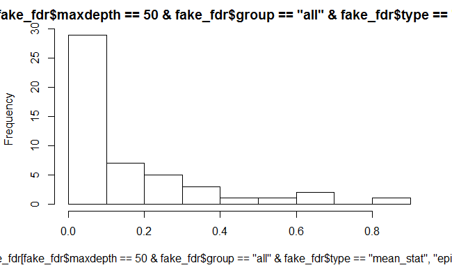

```r
fake_fdr<-read.csv("C:/Users/weidewind/Documents/CMD/Coevolution/Influenza/environment_or_epistasis/expSimCheck/fake_fdr_stats")
hist(fake_fdr[fake_fdr$maxdepth == 50 & fake_fdr$group == "all" & fake_fdr$type == "mean_stat","epi_pvalue"])
```

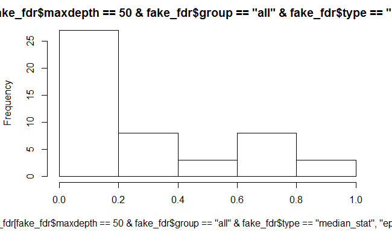

```r
hist(fake_fdr[fake_fdr$maxdepth == 50 & fake_fdr$group == "all" & fake_fdr$type == "median_stat","epi_pvalue"])
```

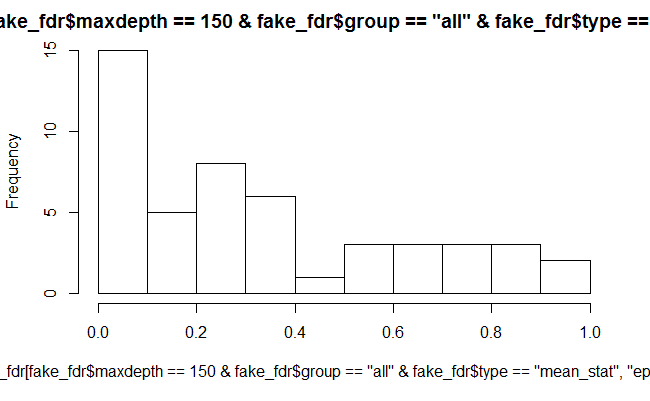

```r
hist(fake_fdr[fake_fdr$maxdepth == 150 & fake_fdr$group == "all" & fake_fdr$type == "mean_stat","epi_pvalue"])
```

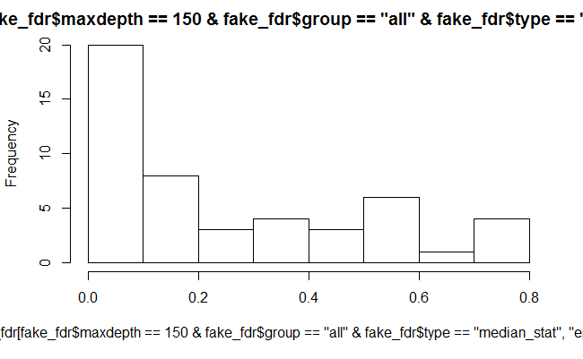

```r
hist(fake_fdr[fake_fdr$maxdepth == 150 & fake_fdr$group == "all" & fake_fdr$type == "median_stat","epi_pvalue"])
```

```r
graphs <- function (stats, simstats){

    lsim <- hist(simstats$maxdepth)
    lfake <- hist(stats$maxlength)
    plot( lsim, col=rgb(0,0,1,1/4), xlim=c(0,350), freq = FALSE, ylim = c(0, 0.01), main = "maxdepths" )  # first histogram
    plot( lfake, col=rgb(1,0,0,1/4), xlim=c(0,350), freq = FALSE,  ylim = c(0, 0.01), add=T)  # second
    old.par <- par(mfrow=c(2, 2))
    hist(stats[stats$mutations <=3, "pvalue_epistasis.median."], main = "median, epi, <=3")
    hist(stats[stats$mutations <=3, "pvalue_environment.median."], main = "median, env, <=3")
    hist(stats[stats$mutations >3, "pvalue_epistasis.median."], main = "median, epi, >3")
    hist(stats[stats$mutations >3, "pvalue_environment.median."], main = "median, env, >3")
    par <- old.par
    old.par <- par(mfrow=c(2, 2))
    hist(stats[stats$mutations <=3, "pvalue_epistasis.mean."], main = "mean, epi, <=3")
    hist(stats[stats$mutations <=3, "pvalue_environment.mean."], main = "mean, env, <=3")
    hist(stats[stats$mutations >3, "pvalue_epistasis.mean."], main = "mean, epi, >3")
    hist(stats[stats$mutations >3, "pvalue_environment.mean."], main = "mean, env, >3")
    par <- old.par
  #  plot(stats$pvalue_epistasis.median., stats$pvalue_epistasis.mean.)
    old.par <- par(mfrow=c(2, 2))
    hist(stats$pvalue_epistasis.median, main = "median, epi")
    hist(stats$pvalue_environment.median, main = "median, env")
    hist(stats$pvalue_epistasis.mean, main = "mean, epi")
    hist(stats$pvalue_environment.mean, main = "mean, env")
    par <- old.par
}
maxlen_graphs<- function (stats, simstats){
   hist(stats[stats$mutations >3 & stats$maxlength >150, "pvalue_environment.median."])
   hist(stats[stats$mutations >3 & stats$maxlength < 90, "pvalue_environment.median."])
   hist(stats[stats$mutations >3 & stats$maxlength >150, "pvalue_environment.mean."])
   hist(stats[stats$mutations >3 & stats$maxlength <90, "pvalue_environment.mean."])
}
```

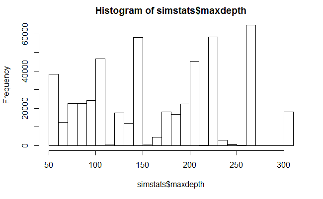

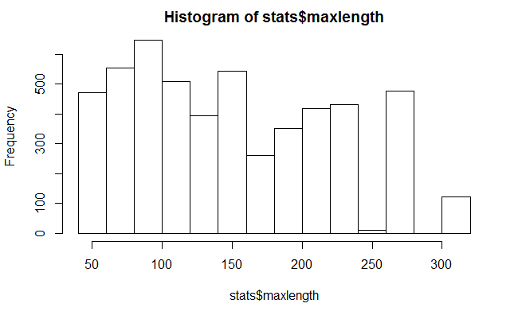

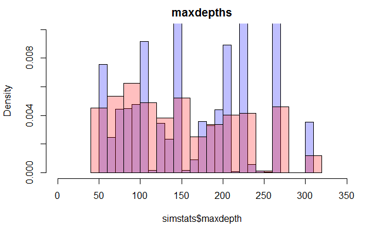

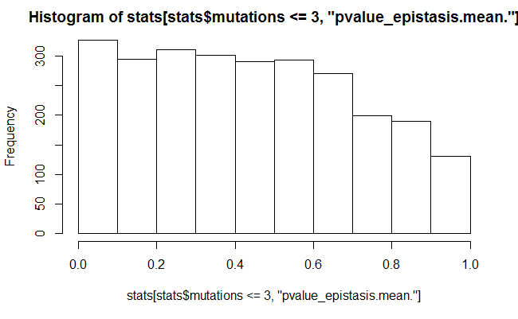

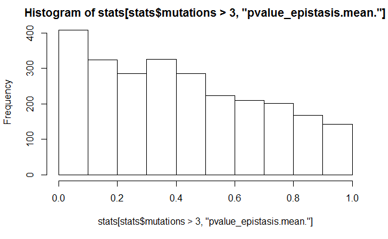

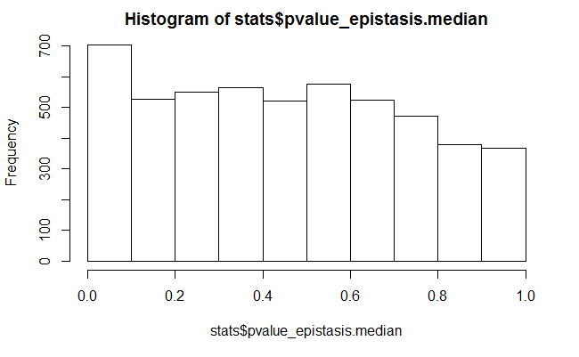

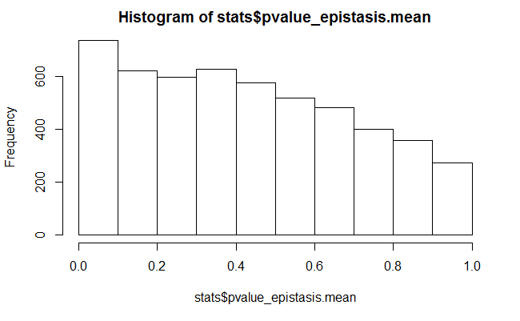

```r
multimetastats<-read.csv("C:/Users/weidewind/Documents/CMD/Coevolution/Influenza/environment_or_epistasis/expSimCheck/meta_sites_with_stats")
multimetasimstats<-read.csv("C:/Users/weidewind/Documents/CMD/Coevolution/Influenza/environment_or_epistasis/expSimCheck/meta_sim_sites_with_stats")
graphs <- function (stats, simstats){

    lsim <- hist(simstats$maxdepth)
    lfake <- hist(stats$maxlength)
    plot( lsim, col=rgb(0,0,1,1/4), xlim=c(0,350), freq = FALSE, ylim = c(0, 0.01), main = "maxdepths" )  # first histogram
    plot( lfake, col=rgb(1,0,0,1/4), xlim=c(0,350), freq = FALSE,  ylim = c(0, 0.01), add=T)  # second
    hist(stats[stats$mutations <=3, "pvalue_epistasis.mean."])
    hist(stats[stats$mutations >3, "pvalue_epistasis.mean."])
  #  plot(stats$pvalue_epistasis.median., stats$pvalue_epistasis.mean.)
    hist(stats$pvalue_epistasis.median)
    hist(stats$pvalue_epistasis.mean)
}
graphs(onemetastats, onemetasimstats)
```

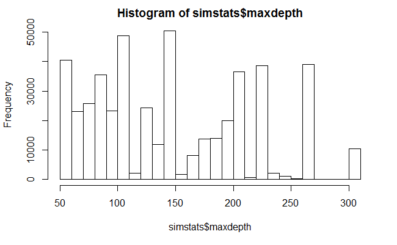

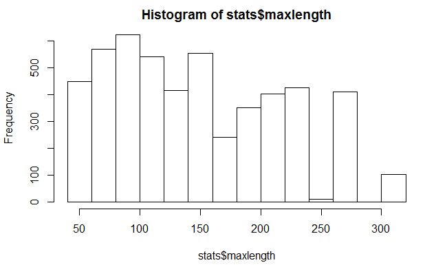

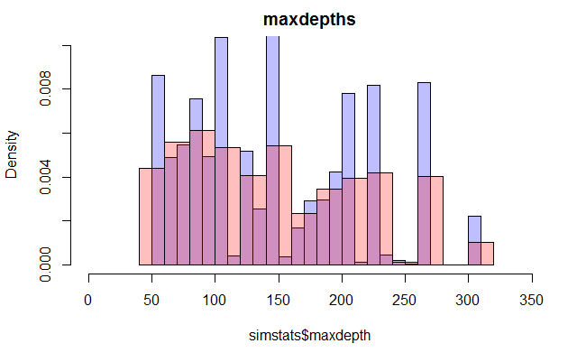

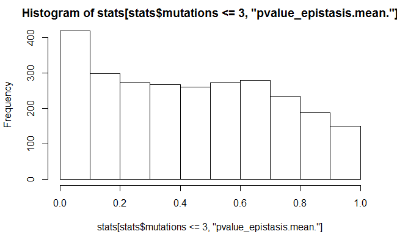

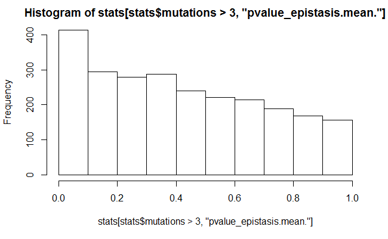

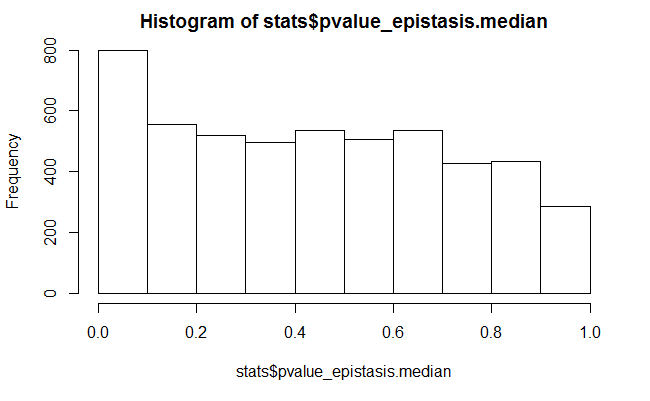

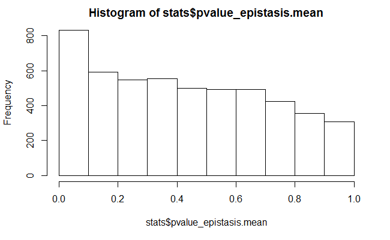

```r
graphs(multimetastats, multimetasimstats)
```

Исправила баг с серединами веток (изменения от 27.02.2017)

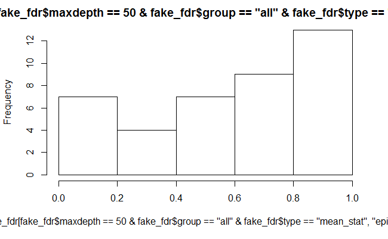

```r
fake_fdr<-read.csv("C:/Users/weidewind/Documents/CMD/Coevolution/Influenza/environment_or_epistasis/expSimCheck/fake_fdr_stats_after_middle")
hist(fake_fdr[fake_fdr$maxdepth == 50 & fake_fdr$group == "all" & fake_fdr$type == "mean_stat","epi_pvalue"])
```

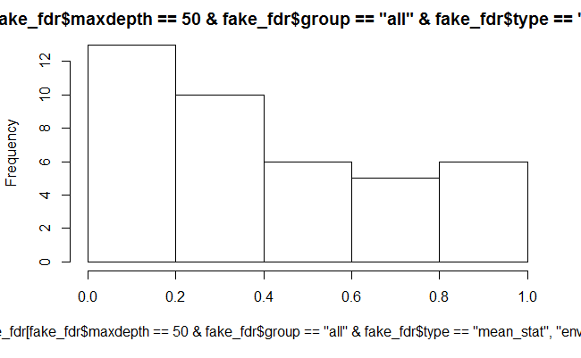

```r
hist(fake_fdr[fake_fdr$maxdepth == 50 & fake_fdr$group == "all" & fake_fdr$type == "mean_stat","env_pvalue"])
```

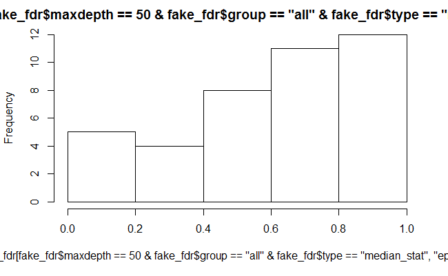

```r
hist(fake_fdr[fake_fdr$maxdepth == 50 & fake_fdr$group == "all" & fake_fdr$type == "median_stat","epi_pvalue"])
```

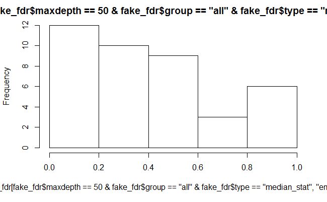

```r
hist(fake_fdr[fake_fdr$maxdepth == 50 & fake_fdr$group == "all" & fake_fdr$type == "median_stat","env_pvalue"])
```

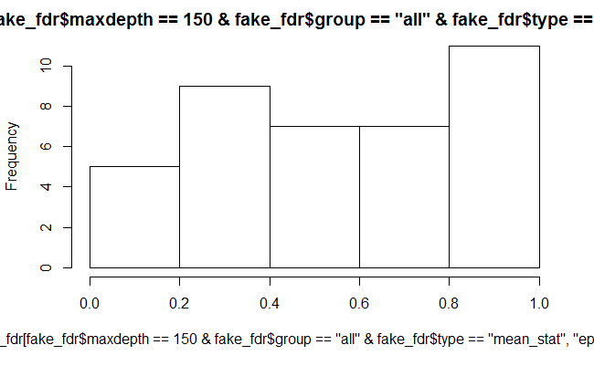

```r
hist(fake_fdr[fake_fdr$maxdepth == 150 & fake_fdr$group == "all" & fake_fdr$type == "mean_stat","epi_pvalue"])
```

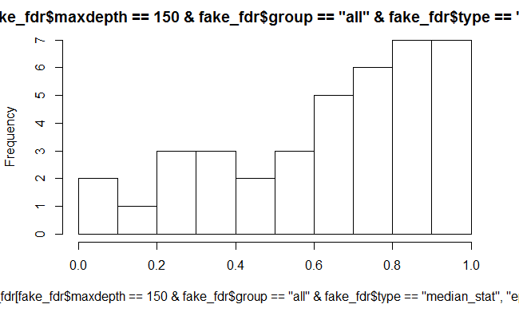

```r
hist(fake_fdr[fake_fdr$maxdepth == 150 & fake_fdr$group == "all" & fake_fdr$type == "median_stat","epi_pvalue"])
```

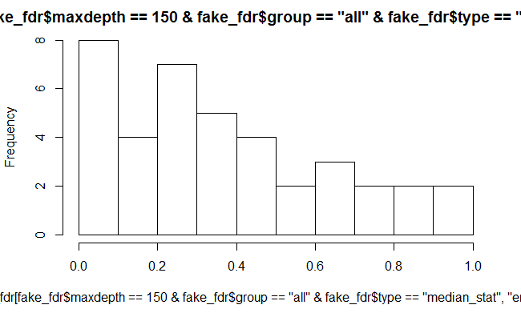

```r
hist(fake_fdr[fake_fdr$maxdepth == 150 & fake_fdr$group == "all" & fake_fdr$type == "median_stat","env_pvalue"])
```

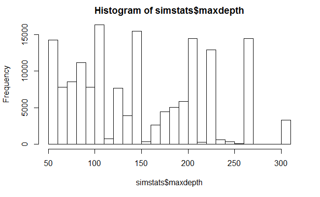

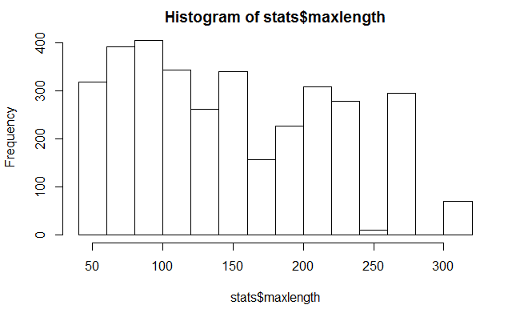

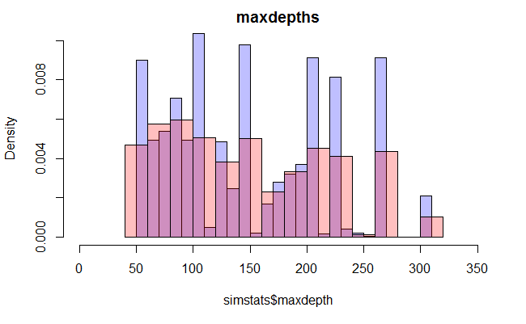

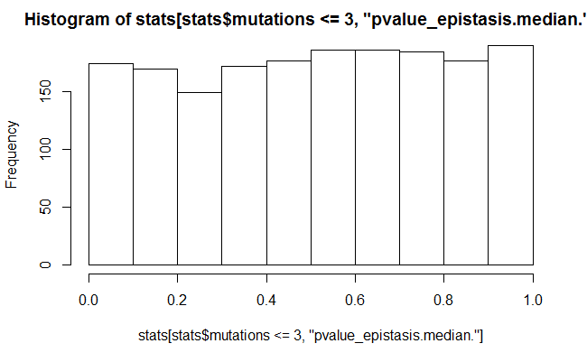

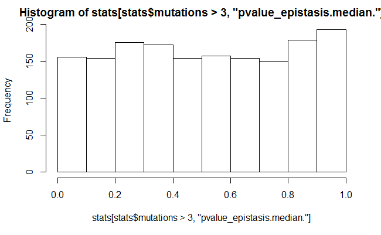

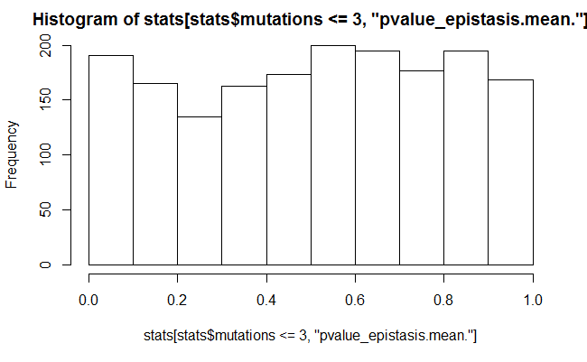

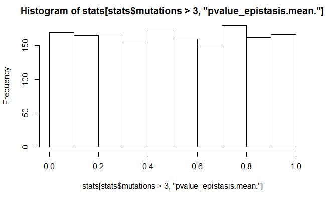

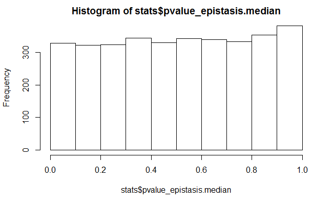

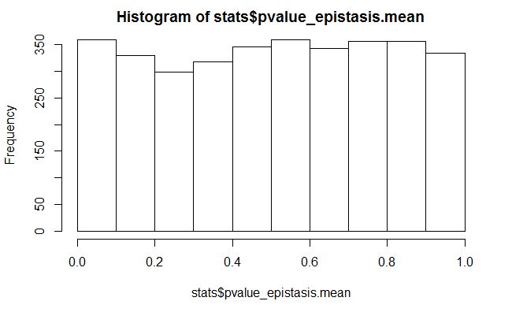

```r
expmetastats<-read.csv("C:/Users/weidewind/Documents/CMD/Coevolution/Influenza/environment_or_epistasis/expSimCheck/meta_sites_with_stats_after_middle")
expmetasimstats<-read.csv("C:/Users/weidewind/Documents/CMD/Coevolution/Influenza/environment_or_epistasis/expSimCheck/meta_sim_sites_with_stats_after_middle")
graphs(expmetastats, expmetasimstats)
```

убран баг 4 < 4 (пересчитаны только сайты) : ничерта не изменилось. Большое количество сайтов с pvalue env = 1: невозможно посадить мутации ближе (именно ближе, а не на то же место), сохранив при этом maxdepth > ограничения ?

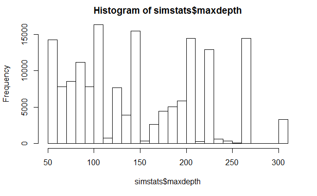

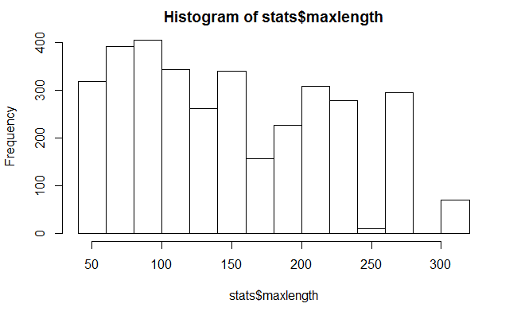

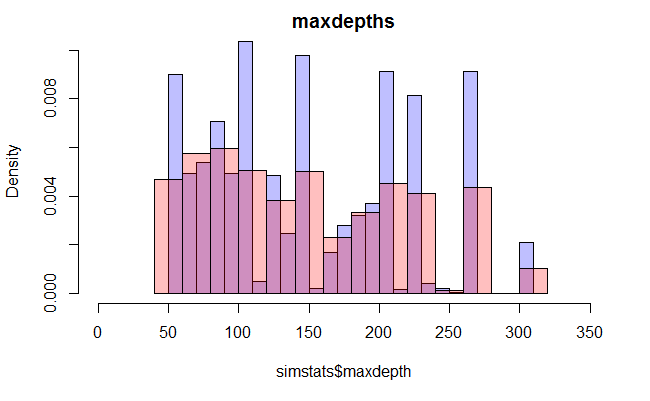

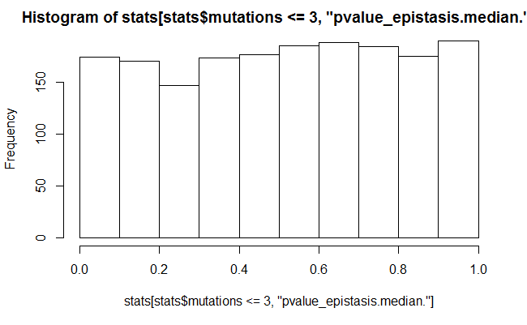

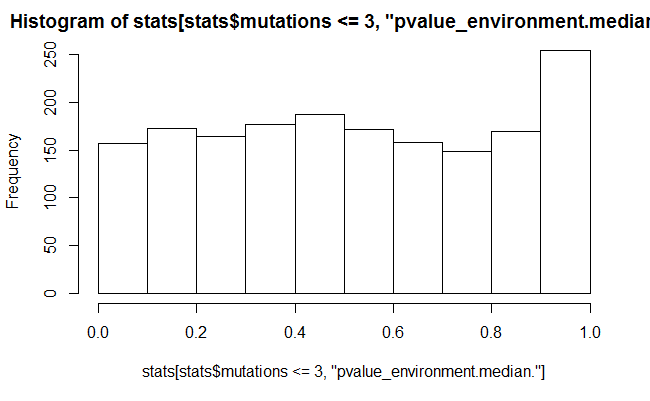

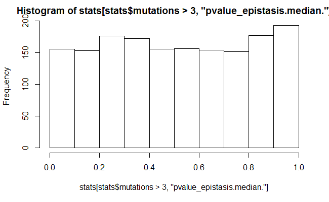

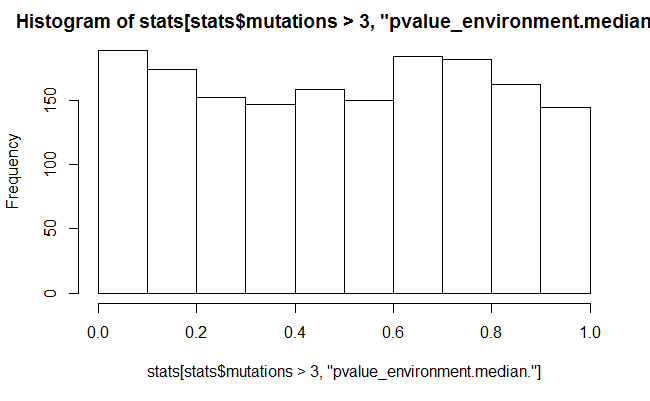

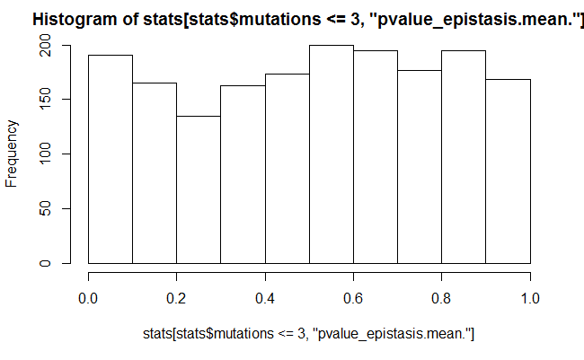

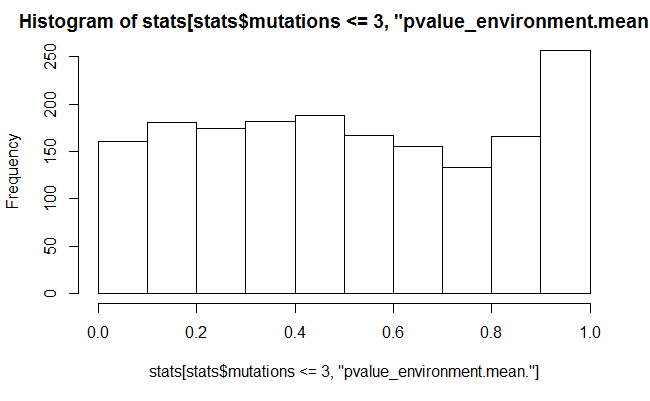

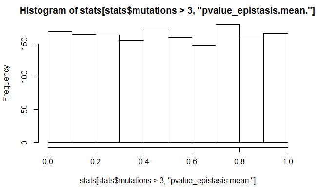

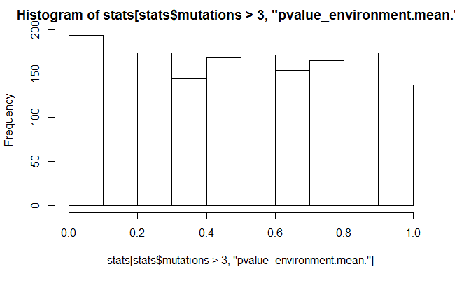

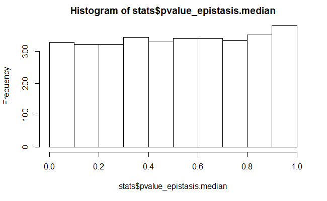

[3 more figures not shown]

```r
expmetastats<-read.csv("C:/Users/weidewind/Documents/CMD/Coevolution/Influenza/environment_or_epistasis/expSimCheck/meta_sites_with_stats_numeric")
expmetasimstats<-read.csv("C:/Users/weidewind/Documents/CMD/Coevolution/Influenza/environment_or_epistasis/expSimCheck/meta_sim_sites_with_stats_numeric")
graphs(expmetastats, expmetasimstats)
```

```r
expmetastats[expmetastats$mutations <= 3 & expmetastats$pvalue_environment.median. > 0.9 & expmetastats$maxlength > 100,]
```

|  | fakeno | site_node | mutations | maxlength | pvalue_epistasis.median. | pvalue_epistasis.mean. | pvalue_environment.median. | pvalue_environment.mean. | iterations | obsmedian | expmedian | obsmean | expmean | X |
| --- | --- | --- | --- | --- | --- | --- | --- | --- | --- | --- | --- | --- | --- | --- |
| 47 | 10 | 276_INTNODE2428 | 2 | 168 | 0.04000000 | 0.04000000 | 0.9600000 | 0.9600000 | 50 | 80.75 | 138.0 | 80.75000 | 125.13610 | NA |
| 59 | 10 | 36_INTNODE2434 | 3 | 269 | 0.06000000 | 0.08000000 | 0.9400000 | 0.9200000 | 50 | 110.50 | 224.0 | 130.66667 | 200.99616 | NA |
| 70 | 10 | 504_INTNODE2428 | 1 | 205 | 0.02000000 | 0.02000000 | 0.9800000 | 0.9800000 | 50 | 33.00 | 163.0 | 33.00000 | 152.47468 | NA |
| 113 | 11 | 213_INTNODE2429 | 2 | 230 | 0.02000000 | 0.02000000 | 0.9800000 | 0.9800000 | 50 | 95.00 | 187.0 | 95.00000 | 168.58191 | NA |
| 115 | 11 | 223_INTNODE2406 | 2 | 143 | 0.02000000 | 0.02000000 | 0.9800000 | 0.9800000 | 50 | 66.50 | 103.0 | 66.50000 | 99.89546 | NA |
| 121 | 11 | 244_INTNODE2406 | 3 | 143 | 0.04000000 | 0.04000000 | 0.9600000 | 0.9600000 | 50 | 54.50 | 103.0 | 55.16667 | 99.63682 | NA |
| 163 | 12 | 11_INTNODE2427 | 2 | 204 | 0.02000000 | 0.02000000 | 0.9800000 | 0.9800000 | 50 | 75.25 | 162.0 | 75.25000 | 150.65515 | NA |
| 165 | 12 | 137_INTNODE2429 | 3 | 169 | 0.08000000 | 0.02000000 | 0.9200000 | 0.9800000 | 50 | 73.50 | 87.0 | 79.16667 | 91.50116 | NA |
| 173 | 12 | 158_INTNODE2434 | 3 | 127 | 0.08510638 | 0.10638298 | 0.9361702 | 0.8936170 | 47 | 70.50 | 91.0 | 65.83333 | 82.47709 | NA |
| 221 | 12 | 393_INTNODE2406 | 2 | 143 | 0.06122449 | 0.06122449 | 0.9387755 | 0.9387755 | 49 | 61.00 | 103.0 | 61.00000 | 99.89037 | NA |

[output cut: 115 more lines]

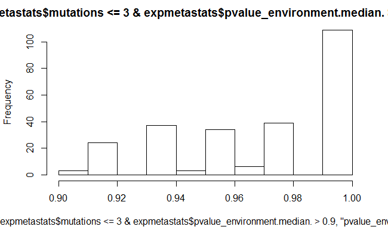

```r
hist(expmetastats[expmetastats$mutations <= 3 & expmetastats$pvalue_environment.median. > 0.9, "pvalue_environment.median."])
```

Fixed site (теперь реальному сайту в симуляции соответствует ровно этот же сайт в том же узле (это сохраняет стопперы на тех же местах))

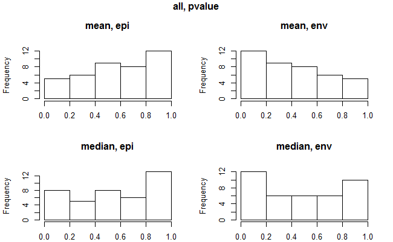

```r
fake_fdr<-read.csv("C:/Users/weidewind/Documents/CMD/Coevolution/Influenza/environment_or_epistasis/expSimCheck/fake_fdr_stats_same_site")
hists (group = "all")
```

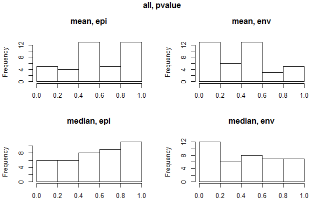

```r
hists (group = "all", maxdepth = 100)
old.par <- par(mfrow=c(2, 2))
```

```r
hist(fake_fdr[fake_fdr$maxdepth == 150 & fake_fdr$group == "all" & fake_fdr$type == "median_stat","epi_pvalue"])
hist(fake_fdr[fake_fdr$maxdepth == 150 & fake_fdr$group == "all" & fake_fdr$type == "median_stat","env_pvalue"])
```

```r
hist(fake_fdr[fake_fdr$maxdepth == 150 & fake_fdr$group == "all" & fake_fdr$type == "mean_stat","epi_pvalue"])
hist(fake_fdr[fake_fdr$maxdepth == 150 & fake_fdr$group == "all" & fake_fdr$type == "mean_stat","env_pvalue"])
```

[figure not shown]

```r
par(old.par)
```

```r
hists <- function (maxdepth = 50, group = "all",  value = "pvalue", breaks = "Sturges"){
  old.par <- par(mfrow=c(2, 2), mar = c(2, 4, 5, 2) + 0.1)
  hist(fake_fdr[fake_fdr$maxdepth == maxdepth & fake_fdr$group == group & fake_fdr$type == "mean_stat", paste(c("epi_", value), collapse = "")], main ="mean, epi",       breaks = breaks)
  hist(fake_fdr[fake_fdr$maxdepth == maxdepth & fake_fdr$group == group & fake_fdr$type == "mean_stat", paste(c("env_", value), collapse = "")], main ="mean, env",       breaks = breaks)
  hist(fake_fdr[fake_fdr$maxdepth == maxdepth & fake_fdr$group == group & fake_fdr$type == "median_stat", paste(c("epi_", value), collapse = "")], main ="median, epi",   breaks = breaks)
  hist(fake_fdr[fake_fdr$maxdepth == maxdepth & fake_fdr$group == group & fake_fdr$type == "median_stat", paste(c("env_", value), collapse = "")], main ="median, env",   breaks = breaks)
  title(paste (group, value, sep = ", "), outer=TRUE, line = -1)
  par(old.par)
}
```

```r
fake_fdr<-read.csv("C:/Users/weidewind/Documents/CMD/Coevolution/Influenza/environment_or_epistasis/expSimCheck/fake_fdr_stats_same_site")

hists (group = "increased_binding")
hists (group = "increased_binding",value = "enrichment_pvalue")
hists (group = "surface")
hists (group = "surface",value = "enrichment_pvalue")
hists (group = "antigenic")
hists (group = "antigenic",value = "enrichment_pvalue")
```

[output not shown]